# Lab0

Mariana Cubero/ mcubero@cenat.ac.cr

19/8/2020

## Workflow

Normalmente mi proceso de trabajo depende mucho del tipo de proyecto en el que esté trabajando, los procesos de recolección de datos normalmente son más automáticos. Mi trabajo de día a día empeiza un poco diferente porque normalmente partimos de los datos que ya tenemos, pero tenemos que plantear cómo usarlos para comprender el gran problema que da origen al proyecto de investigación. Entonces, asumiento que ya tenemos los datos ese paso de “¿la captura” para mi es “cómo los usamos?”, “¿con cuáles otras capas podemos complementar esto?”. En la siguiente figura presento un ejemplo de los pasos que trato de seguir en el trabajo.

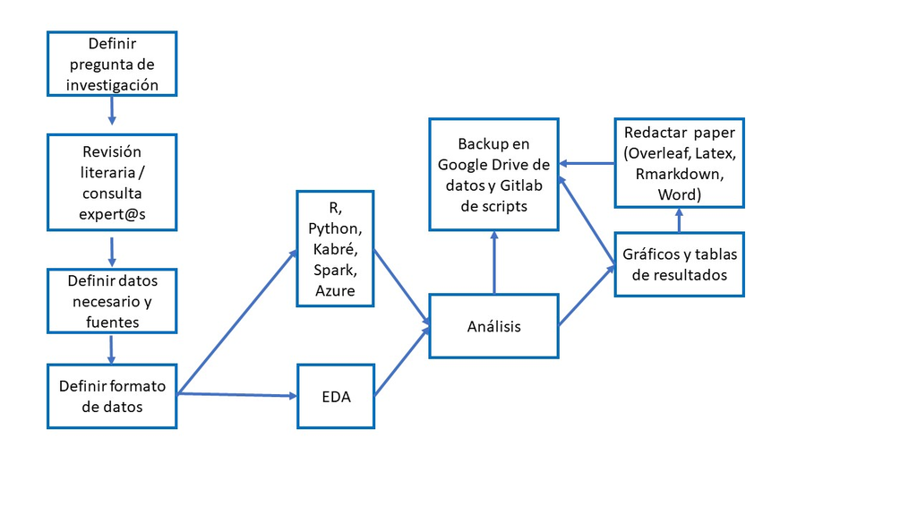

Claro, no siempre se sigue al pie de la letra, sin embargo, en cuanto a la organización de archivos siempre trato de tener algunos componentes básicos en mi directorio de trabajo para cada proyecto:

- Datos crudos
- Scripts
- Resultados

En cuanto a los 6 principios que comentan en el blog

- Transparencia: Creo que sí es transparente, permite ubicarse en la etapa en la que estamos y las herramientas que se usan. Dado que normalmente trabajo con grupos de investigación diversos y normalmente no técnicos este workflow nos ha permitido entendernos en las diferentes etapas de proceso.
- Mantenibilidad: Es un poco “tieso” a veces cuando hay que plantearse nuevas preguntas o los resultados apuntan a replantear la línea de trabajo que estamos siguiento.
- Modularidad:sí se adapta a este principio y lo hemos encontrado muy valioso para los avances del proyecto.
- Portabilidad: sí es portable ya que los directorios son compartidos.
- Reproducibilidad: Sí, actualmente se trabaja en un esfuerzo mayor para documentar todos los procesos, scripts y visualizaciones que se haga de manera que se puedan entender y replicar apropiadamente a nivel interno.
- Efficiencia: Moderadamente eficiente, como mencionpe anteriormente puede ser un poco “tieso” entonces a veces puede ser un poco tedioso.